# Homework 6: Linear Models

Natalie Boychuk

12/7/2020

## Problem 1

```r
  homicide_df =
    read_csv("data/homicide-data.csv") %>%
    mutate(
      city_state = str_c(city, state, sep = "_"),
      resolved = case_when(
        disposition == "Closed without arrest" ~ 0,
        disposition == "Open/No arrest" ~ 0,
        disposition == "Closed by arrest" ~ 1
        )) %>%
    filter((city_state != "Tulsa_AL"),
           (city_state != "Phoenix_AZ"),
           (city_state != "Kansas City_MO"),
           (city_state != "Dallas_TX"),
           (victim_race %in% c("White", "Black"))) %>%
    select(city_state, resolved, victim_age, victim_race, victim_sex) %>%
    mutate(victim_age = as.numeric(victim_age))
baltimore_df =
  homicide_df %>%
  filter(city_state == "Baltimore_MD")

glm(resolved ~ victim_age + victim_race + victim_sex,
    data = baltimore_df,
    family = binomial()) %>%
  broom::tidy() %>%
  mutate(
    OR = exp(estimate),
    CI_lower = exp(estimate - 1.96 * std.error),
    CI_upper = exp(estimate + 1.96 * std.error)
  ) %>%
  select(term, OR, starts_with("CI")) %>%
  knitr::kable(digits = 3)
```

| term | OR | CI_lower | CI_upper |
| --- | --- | --- | --- |
| (Intercept) | 1.363 | 0.975 | 1.907 |
| victim_age | 0.993 | 0.987 | 1.000 |
| victim_raceWhite | 2.320 | 1.648 | 3.268 |
| victim_sexMale | 0.426 | 0.325 | 0.558 |

Across cities

```r
models_results_df =
  homicide_df %>%
  nest(data = -city_state) %>%
mutate(
  models =
    map(.x = data, ~glm(glm(resolved ~ victim_age + victim_race + victim_sex, data = .x, family = binomial()))),
  results = map(models, broom::tidy)
  ) %>%
select(city_state, results) %>%
 unnest(results) %>%
  mutate(
    OR = exp(estimate),
    CI_lower = exp(estimate - 1.96 * std.error),
    CI_upper = exp(estimate + 1.96 * std.error)
  ) %>%
  select(city_state, term, OR, starts_with("CI"))
```

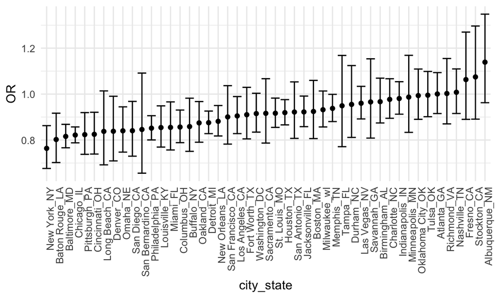

```r
models_results_df %>%
  filter(term == "victim_sexMale") %>%
  mutate(city_state = fct_reorder(city_state, OR)) %>%
  ggplot(aes(x = city_state, y = OR)) +
  geom_point() +
  geom_errorbar(aes(ymin = CI_lower, ymax = CI_upper)) +
  theme(axis.text.x = element_text(angle = 90, hjust = 1))
```

## Problem 2

```r
birthweight_df =
  read_csv("data/birthweight.csv") %>%
  mutate(mrace = as.factor(mrace),
         malform = as.factor(malform))
## Look for missing data

tail(birthweight_df,100)
```

```
## # A tibble: 100 x 20
##    babysex bhead blength   bwt delwt fincome frace gaweeks malform menarche
##      <dbl> <dbl>   <dbl> <dbl> <dbl>   <dbl> <dbl>   <dbl> <fct>      <dbl>
##  1       1    34      50  2608   158      15     2    40.1 0             12
##  2       2    34      50  3402   157      15     2    37.7 0             11
##  3       2    35      52  3203   150      35     2    49   0             13
##  4       1    36      53  3657   154      45     2    40.6 0             12
##  5       1    33      49  2750   123      25     2    39   0             14
##  6       1    35      52  3005   220       5     2    42.1 0             12
##  7       2    33      48  2693   143      25     2    32.1 0             11
##  8       1    35      51  3572   157      25     2    39.1 0             14
##  9       1    33      51  2948   158      25     2    37.4 0             13
## 10       2    34      49  3147   138      25     2    40.6 0             14
## # … with 90 more rows, and 10 more variables: mheight <dbl>, momage <dbl>,
## #   mrace <fct>, parity <dbl>, pnumlbw <dbl>, pnumsga <dbl>, ppbmi <dbl>,
## #   ppwt <dbl>, smoken <dbl>, wtgain <dbl>
```

```r
head(birthweight_df,100)
```

```
## # A tibble: 100 x 20
##    babysex bhead blength   bwt delwt fincome frace gaweeks malform menarche
##      <dbl> <dbl>   <dbl> <dbl> <dbl>   <dbl> <dbl>   <dbl> <fct>      <dbl>
##  1       2    34      51  3629   177      35     1    39.9 0             13
##  2       1    34      48  3062   156      65     2    25.9 0             14
##  3       2    36      50  3345   148      85     1    39.9 0             12
##  4       1    34      52  3062   157      55     1    40   0             14
##  5       2    34      52  3374   156       5     1    41.6 0             13
##  6       1    33      52  3374   129      55     1    40.7 0             12
##  7       2    33      46  2523   126      96     2    40.3 0             14
##  8       2    33      49  2778   140       5     1    37.4 0             12
##  9       1    36      52  3515   146      85     1    40.3 0             11
## 10       1    33      50  3459   169      75     2    40.7 0             12
## # … with 90 more rows, and 10 more variables: mheight <dbl>, momage <dbl>,
## #   mrace <fct>, parity <dbl>, pnumlbw <dbl>, pnumsga <dbl>, ppbmi <dbl>,
## #   ppwt <dbl>, smoken <dbl>, wtgain <dbl>
```

```r
skimr::skim(birthweight_df)
```

Data summary

| Name | birthweight_df |
| --- | --- |
| Number of rows | 4342 |
| Number of columns | 20 |
| _______________________ |  |
| Column type frequency: |  |
| factor | 2 |
| numeric | 18 |
| ________________________ |  |
| Group variables | None |

**Variable type: factor**

| skim_variable | n_missing | complete_rate | ordered | n_unique | top_counts |
| --- | --- | --- | --- | --- | --- |
| malform | 0 | 1 | FALSE | 2 | 0: 4327, 1: 15 |
| mrace | 0 | 1 | FALSE | 4 | 1: 2147, 2: 1909, 4: 243, 3: 43 |

**Variable type: numeric**

| skim_variable | n_missing | complete_rate | mean | sd | p0 | p25 | p50 | p75 | p100 | hist |
| --- | --- | --- | --- | --- | --- | --- | --- | --- | --- | --- |
| babysex | 0 | 1 | 1.49 | 0.50 | 1.00 | 1.00 | 1.00 | 2.00 | 2.0 | ▇▁▁▁▇ |
| bhead | 0 | 1 | 33.65 | 1.62 | 21.00 | 33.00 | 34.00 | 35.00 | 41.0 | ▁▁▆▇▁ |
| blength | 0 | 1 | 49.75 | 2.72 | 20.00 | 48.00 | 50.00 | 51.00 | 63.0 | ▁▁▁▇▁ |
| bwt | 0 | 1 | 3114.40 | 512.15 | 595.00 | 2807.00 | 3132.50 | 3459.00 | 4791.0 | ▁▁▇▇▁ |
| delwt | 0 | 1 | 145.57 | 22.21 | 86.00 | 131.00 | 143.00 | 157.00 | 334.0 | ▅▇▁▁▁ |
| fincome | 0 | 1 | 44.11 | 25.98 | 0.00 | 25.00 | 35.00 | 65.00 | 96.0 | ▃▇▅▂▃ |
| frace | 0 | 1 | 1.66 | 0.85 | 1.00 | 1.00 | 2.00 | 2.00 | 8.0 | ▇▁▁▁▁ |
| gaweeks | 0 | 1 | 39.43 | 3.15 | 17.70 | 38.30 | 39.90 | 41.10 | 51.3 | ▁▁▂▇▁ |
| menarche | 0 | 1 | 12.51 | 1.48 | 0.00 | 12.00 | 12.00 | 13.00 | 19.0 | ▁▁▂▇▁ |
| mheight | 0 | 1 | 63.49 | 2.66 | 48.00 | 62.00 | 63.00 | 65.00 | 77.0 | ▁▁▇▂▁ |
| momage | 0 | 1 | 20.30 | 3.88 | 12.00 | 18.00 | 20.00 | 22.00 | 44.0 | ▅▇▂▁▁ |
| parity | 0 | 1 | 0.00 | 0.10 | 0.00 | 0.00 | 0.00 | 0.00 | 6.0 | ▇▁▁▁▁ |
| pnumlbw | 0 | 1 | 0.00 | 0.00 | 0.00 | 0.00 | 0.00 | 0.00 | 0.0 | ▁▁▇▁▁ |
| pnumsga | 0 | 1 | 0.00 | 0.00 | 0.00 | 0.00 | 0.00 | 0.00 | 0.0 | ▁▁▇▁▁ |
| ppbmi | 0 | 1 | 21.57 | 3.18 | 13.07 | 19.53 | 21.03 | 22.91 | 46.1 | ▃▇▁▁▁ |
| ppwt | 0 | 1 | 123.49 | 20.16 | 70.00 | 110.00 | 120.00 | 134.00 | 287.0 | ▅▇▁▁▁ |
| smoken | 0 | 1 | 4.15 | 7.41 | 0.00 | 0.00 | 0.00 | 5.00 | 60.0 | ▇▁▁▁▁ |
| wtgain | 0 | 1 | 22.08 | 10.94 | -46.00 | 15.00 | 22.00 | 28.00 | 89.0 | ▁▁▇▁▁ |

```r
## it all looks okay to me. Variable names are already clean and columns look good
```

Given background knowledge/research (I work for a lab that studies maternal/infant mortality and morbidity and I did a quick literature search [ex: (https://www.marchofdimes.org/complications/low-birthweight.aspx)]), I first hypothesize that premature is the primary cause of low birthweight. I further hypothesize that cigarette smoking, mother’s weight at delivery, mother’s age at delivery, maternal race, and family income might confound this relationship.

I would also like to be clear that I am not hypothesizing that race in and of itself is a cause of low birthweight; rather, structural inequalities associated with being a Black mother in the United States cause low birthweight in infants.

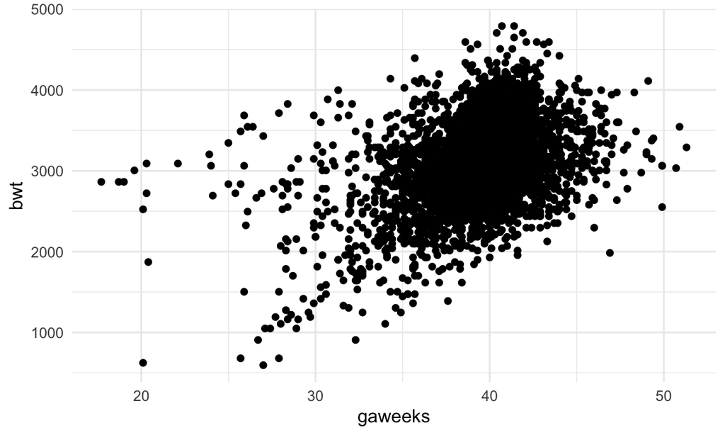

```r
birthweight_df %>%
  ggplot(aes(x = gaweeks, y = bwt)) + geom_point()
```

```r
glm(bwt ~ gaweeks + mrace + smoken + momage + fincome + smoken * ppwt, data = birthweight_df) %>%
  broom::tidy() %>%
  knitr::kable()
```

| term | estimate | std.error | statistic | p.value |
| --- | --- | --- | --- | --- |
| (Intercept) | 518.3215278 | 101.9666119 | 5.0832475 | 0.0000004 |
| gaweeks | 58.0780785 | 2.1468346 | 27.0528896 | 0.0000000 |
| mrace2 | -288.8459979 | 16.0837909 | -17.9588257 | 0.0000000 |
| mrace3 | -81.2075280 | 68.5532883 | -1.1845898 | 0.2362446 |
| mrace4 | -157.7777138 | 30.3850919 | -5.1926028 | 0.0000002 |
| smoken | -15.9947614 | 5.4497149 | -2.9349721 | 0.0033533 |
| momage | -2.1286471 | 1.9079943 | -1.1156464 | 0.2646354 |
| fincome | 0.3719107 | 0.2856701 | 1.3018889 | 0.1930236 |
| ppwt | 4.1824551 | 0.3947002 | 10.5965351 | 0.0000000 |
| smoken:ppwt | 0.0377123 | 0.0428832 | 0.8794196 | 0.3792226 |

From this initial model, it does not look like the mother’s age at delivery or family income is adding anything to the model. Also, it looks like mother’s pre-pregnancy weight is significant but not in interaction with smoking. For parsimony, I’ll drop these predictors that were insignificant in the model using a backwards stepwise approach, removing one at a time.

```r
glm(bwt ~ gaweeks + mrace + smoken + momage + fincome + ppwt, data = birthweight_df) %>%
  broom::tidy() %>%
  knitr::kable()
```

| term | estimate | std.error | statistic | p.value |
| --- | --- | --- | --- | --- |
| (Intercept) | 494.9218595 | 98.4311596 | 5.028102 | 0.0000005 |
| gaweeks | 58.0655836 | 2.1467314 | 27.048369 | 0.0000000 |
| mrace2 | -288.3171638 | 16.0721251 | -17.938957 | 0.0000000 |
| mrace3 | -77.9337129 | 68.4503453 | -1.138544 | 0.2549564 |
| mrace4 | -157.0660197 | 30.3735185 | -5.171150 | 0.0000002 |
| smoken | -11.2720755 | 0.9273463 | -12.155195 | 0.0000000 |
| momage | -2.0770096 | 1.9070407 | -1.089127 | 0.2761585 |
| fincome | 0.3747529 | 0.2856443 | 1.311956 | 0.1896043 |
| ppwt | 4.3635292 | 0.3367295 | 12.958559 | 0.0000000 |

Fincome is still not significant so I will also drop this variable.

```r
glm(bwt ~ gaweeks + mrace + smoken + momage + ppwt, data = birthweight_df) %>%
  broom::tidy() %>%
  knitr::kable()
```

| term | estimate | std.error | statistic | p.value |
| --- | --- | --- | --- | --- |
| (Intercept) | 500.576278 | 98.3449391 | 5.0900055 | 0.0000004 |
| gaweeks | 58.134104 | 2.1462746 | 27.0860517 | 0.0000000 |
| mrace2 | -294.782619 | 15.2992144 | -19.2678272 | 0.0000000 |
| mrace3 | -83.908425 | 68.3043680 | -1.2284489 | 0.2193452 |
| mrace4 | -163.135841 | 30.0215872 | -5.4339513 | 0.0000001 |
| smoken | -11.302973 | 0.9271243 | -12.1914320 | 0.0000000 |
| momage | -1.542262 | 1.8631285 | -0.8277808 | 0.4078403 |
| ppwt | 4.369095 | 0.3367308 | 12.9750365 | 0.0000000 |

I will also drop momage, which is not significant when accounting for the other variables.

```r
bwmodel = glm(bwt ~ gaweeks + mrace + smoken + ppwt, data = birthweight_df)

bwmodel %>%
  broom::tidy() %>%
  knitr::kable()
```

| term | estimate | std.error | statistic | p.value |
| --- | --- | --- | --- | --- |
| (Intercept) | 475.653412 | 93.6194201 | 5.080713 | 0.0000004 |
| gaweeks | 58.055545 | 2.1440975 | 27.076915 | 0.0000000 |
| mrace2 | -290.598464 | 14.4395699 | -20.125147 | 0.0000000 |
| mrace3 | -90.617728 | 67.8193108 | -1.336164 | 0.1815658 |
| mrace4 | -160.833546 | 29.8913910 | -5.380598 | 0.0000001 |
| smoken | -11.295215 | 0.9270433 | -12.184129 | 0.0000000 |
| ppwt | 4.326819 | 0.3328233 | 13.000349 | 0.0000000 |

Okay, I’m happy with this model! Now I’m going to plot the model residuals and fitted values.

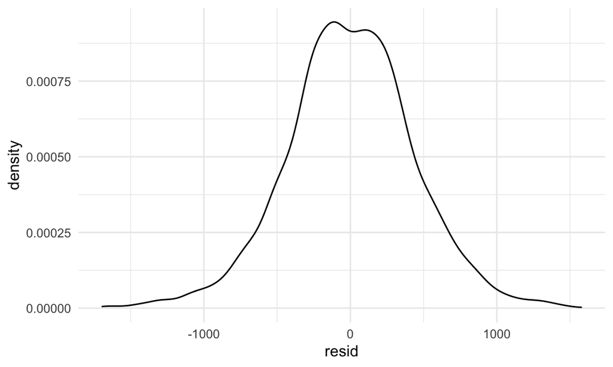

```r
birthweight_df %>%
  add_residuals(bwmodel) %>%
      ggplot(aes(x = resid)) + geom_density()
```

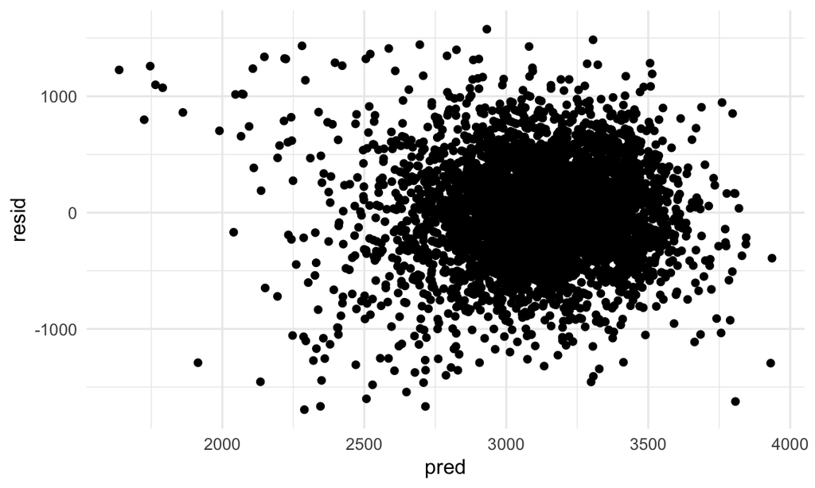

```r
## Slightly skewed but not too bad. Mostly centered around 0.

birthweight_df %>%
  add_residuals(bwmodel) %>%
    add_predictions(bwmodel) %>%
      ggplot(aes(x = pred, y = resid)) + geom_point()
```

```r
# This looks mostly okay, since it's almost the same residual plot as what was shown in lecture. There does seem to maybe be something weird happening in the top-left of the plot but for the purposes of this course I'll move on.
```

Model 2 (from HW):

```r
model2 = glm(bwt ~ blength + gaweeks, data = birthweight_df)
```

Model 3 (from HW):

```r
model3 = glm(bwt ~ bhead * blength * babysex, data = birthweight_df)
```

Now I’m going to compare my model with the 2 provided models using cross-validation.

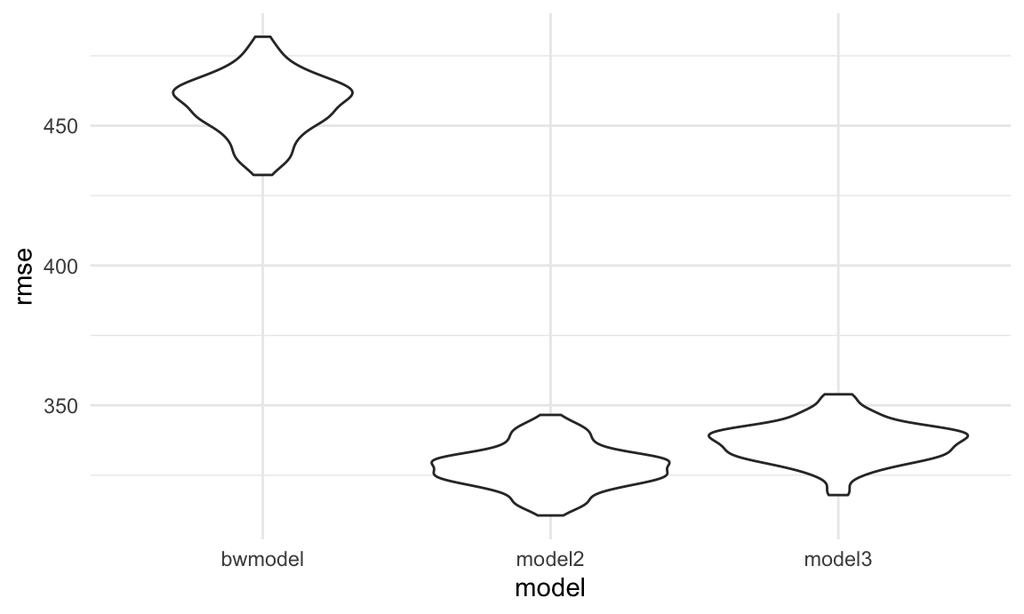

```r
cv_df =
  crossv_mc(birthweight_df, 100) %>%
   mutate(
    train = map(train, as_tibble),
    test = map(test, as_tibble))

cv_df =
  cv_df %>%
  mutate(
    bwmodel = map(train, ~mgcv::gam(bwt ~ s(gaweeks + mrace + smoken + ppwt), data = birthweight_df)),
    model2 = map(train, ~mgcv::gam(bwt ~ s(blength + gaweeks), data = birthweight_df)),
    model3 = map(train, ~mgcv::gam(bwt ~ s(bhead * blength * babysex), data = birthweight_df))) %>%
  mutate(
    rmse_bwmodel = map2_dbl(bwmodel, test, ~rmse(model = .x, data = .y)),
    rmse_model2 = map2_dbl(model2, test, ~rmse(model = .x, data = .y)),
    rmse_model3 = map2_dbl(model3, test, ~rmse(model = .x, data = .y)))
predic_error =
cv_df %>%
  select(starts_with("rmse")) %>%
  pivot_longer(
    everything(),
    names_to = "model",
    values_to = "rmse",
    names_prefix = "rmse_") %>%
  mutate(model = fct_inorder(model)) %>%
  ggplot(aes(x = model, y = rmse)) + geom_violin()

predic_error
```

```r
## Clearly mine is performing the worst (sad!)
```

## Problem 3

```r
weather_df =
  rnoaa::meteo_pull_monitors(
    c("USW00094728"),
    var = c("PRCP", "TMIN", "TMAX"),
    date_min = "2017-01-01",
    date_max = "2017-12-31") %>%
  mutate(
    name = recode(id, USW00094728 = "CentralPark_NY"),
    tmin = tmin / 10,
    tmax = tmax / 10) %>%
  select(name, id, everything())
```

```
## using cached file: /Users/natalieboychuk/Library/Caches/R/noaa_ghcnd/USW00094728.dly
```

```
## date created (size, mb): 2020-10-04 21:34:58 (7.522)
```

```
## file min/max dates: 1869-01-01 / 2020-10-31
```

```r
model_weather =
  lm(tmax ~ tmin, data = weather_df)
```

```r
rsquare =
model_weather %>%
  broom::glance() %>%
  select(r.squared)

logb0b1 =
model_weather %>%
  broom::tidy() %>%
  pivot_wider(term,
              names_from = "term",
              values_from = "estimate") %>%
    mutate(logvalue =
           log(`(Intercept)` * tmin)) %>%
              select(logvalue)
```

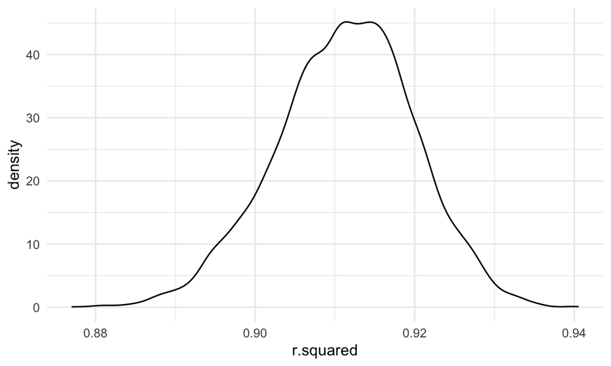

```r
bootstraps =
  weather_df %>%
  bootstrap(5000, id = "strap_number") %>%
  mutate(
    fit = map(.x = strap, ~lm(tmax ~ tmin, data = .x))) %>%
                mutate(rsquare = map(fit, broom::glance),
                      logvalue = map(fit, broom::tidy)) %>%
  unnest(rsquare, logvalue) %>%
  select(strap_number, term, r.squared, estimate) %>%
  mutate(term=str_replace(term,"\\(Intercept\\)","intercept"))
rsquarevalue_boostraps =
  bootstraps %>%
  select(strap_number, r.squared) %>%
  ggplot(aes(x = r.squared)) + geom_density()

rsquarevalue_boostraps
```

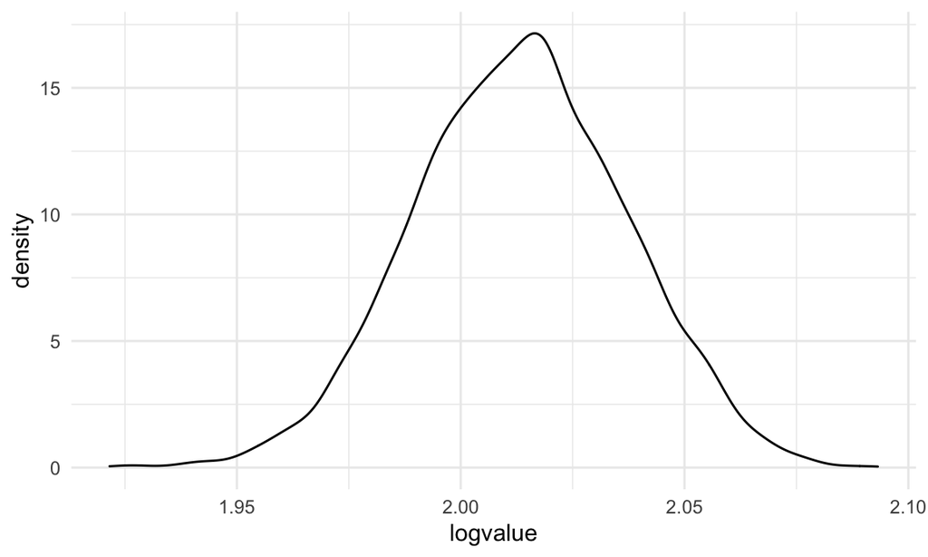

```r
logvalue_bootstraps =
bootstraps %>%
     pivot_wider(term,
              names_from = "term",
              values_from = "estimate") %>%
    unnest(intercept, tmin) %>%
    mutate(logvalue =
           log(intercept * tmin)) %>%
  ggplot(aes(x = logvalue)) + geom_density()
logvalue_bootstraps
```

The rsquared value seems to be centered around 0.91 and is slightly left-skewed, but is otherwise fairly symmetrical.

The logvalue variable has a more symmetrical distribution around 2.02. There may be a very slight skewness to the right but it’s hard to tell.

```r
final_logvalue =
bootstraps %>%
     pivot_wider(term,
              names_from = "term",
              values_from = "estimate") %>%
    unnest(intercept, tmin) %>%
    mutate(logvalue =
           log(intercept * tmin)) %>%
  summarize(
    ci_lower = quantile(logvalue, 0.025),
    ci_upper = quantile(logvalue, 0.975)) %>%
    knitr::kable()
final_logvalue
```

| ci_lower | ci_upper |
| --- | --- |
| 1.966942 | 2.058528 |

```r
final_rsquared =
  bootstraps %>%
  select(strap_number, r.squared) %>%
  summarize(
    ci_lower = quantile(r.squared, 0.025),
    ci_upper = quantile(r.squared, 0.975)) %>%
  knitr::kable()

final_rsquared
```

| ci_lower | ci_upper |
| --- | --- |
| 0.8936977 | 0.9274807 |